# Homework4

Yuchen SHAO

2025-02-16

## Question 4.1

### Part A

The white noise process $\epsilon_n$ is assumed to have a variance $\sigma^2$, and its autocovariance is:

$$\gamma_{\epsilon}(h) = \sigma^2 \quad \text{for} \quad h = 0$$

and

$$\gamma_{\epsilon}(h) = 0 \quad \text{for} \quad h \neq 0.$$

Thus, the spectrum of the white noise process, $\lambda_{\epsilon}(\omega)$, is obtained by taking the Fourier transform of the autocovariance:

$$\lambda_{\epsilon}(\omega) = \sum_{h=-\infty}^{\infty}
\gamma_{\epsilon}(h)e^{-i\omega h} = \sigma^2,$$

where $\omega$ is the angular frequency, measured in radians per unit time.

Meanwhile, the autocovariance function for $\epsilon_n$ can be written as:

$$\gamma_{\epsilon}(h) = \text{Cov}(\epsilon_{n+h}, \epsilon_n)$$

Expanding the terms for the covariance:

$$\gamma_{\epsilon}(h) = \text{Cov}\left(X_{n+h} - 1.5X_{n+h-1} +
0.8X_{n+h-2}, X_n - 1.5X_{n-1} + 0.8X_{n-2}\right)$$

This expression simplifies to:

$$\gamma_{\epsilon}(h) = \text{Cov}(X_{n+h}, X_n) - 1.5 \,
\text{Cov}(X_{n+h}, X_{n-1}) + 0.8 \, \text{Cov}(X_{n+h}, X_{n-2})$$

$$- 1.5 \, \text{Cov}(X_{n+h-1}, X_n) + 1.5^2 \, \text{Cov}(X_{n+h-1},
X_{n-1}) - 1.5 \times 0.8 \, \text{Cov}(X_{n+h-1}, X_{n-2})$$

$$+ 0.8 \, \text{Cov}(X_{n+h-2}, X_n) - 0.8 \times 1.5 \,
\text{Cov}(X_{n+h-2}, X_{n-1}) + 0.8^2 \, \text{Cov}(X_{n+h-2}, X_{n-2})$$

We group the terms by their corresponding lags:

$$\gamma_{\epsilon}(h) = (1 + 1.5^2 + 0.8^2)\gamma_X(h) + (-1.5 - 1.5
\times 0.8)\gamma_X(h+1) + 0.8\gamma_X(h+2) + \gamma_X(h-2)$$

Thus, the simplified expression for $\gamma_{\epsilon}(h)$ becomes:

$$\gamma_{\epsilon}(h) = 3.89\gamma_X(h) - 2.7\gamma_X(h+1) +
0.8\gamma_X(h+2) + \gamma_X(h-2)$$

To find the spectral density of the process, we compute the Fourier transform of $\gamma_{\epsilon}(h)$:

$$\lambda_{\epsilon}(\omega) = \sum_{h=-\infty}^{\infty}
\gamma_{\epsilon}(h)e^{-i\omega h}$$

Substituting the expression for $\gamma_{\epsilon}(h)$:

$$\lambda_{\epsilon}(\omega) = \sum_{h=-\infty}^{\infty} \left\{
3.89\gamma_X(h) - 2.7\left[\gamma_X(h+1) + \gamma_X(h-1)\right] +
0.8\left[\gamma_X(h+2) + \gamma_X(h-2)\right] \right\} e^{-i\omega h}$$

We have the following sums involving shifted autocovariances:

$$\sum_{h=-\infty}^{\infty} \gamma_X(h+1)e^{-i\omega h} = e^{i\omega}
\sum_{h'=-\infty}^{\infty} \gamma_X(h') e^{-i\omega h'} =
e^{i\omega} \lambda_X(\omega)$$

Similarly:

$$\sum_{h=-\infty}^{\infty} \gamma_X(h-1)e^{-i\omega h} = e^{-i\omega}
\lambda_X(\omega)$$

$$\sum_{h=-\infty}^{\infty} \gamma_X(h-2)e^{-i\omega h} = e^{-2i\omega}
\lambda_X(\omega)$$

Thus, we can write the spectral density as:

$$\sigma^2 = \lambda_{\epsilon}(\omega) = 3.89\lambda_X(\omega) -
2.7\left(e^{i\omega} + e^{-i\omega}\right)\lambda_X(\omega) +
0.8\left(e^{2i\omega} + e^{-2i\omega}\right)\lambda_X(\omega)$$

Finally, we have the expression for the spectral density of $X_n$:

$$\lambda_X(\omega) = \frac{\sigma^2}{3.89 - 5.4 \cos(\omega) + 1.6
\cos(2\omega)}$$

```r
library('TSA')
```

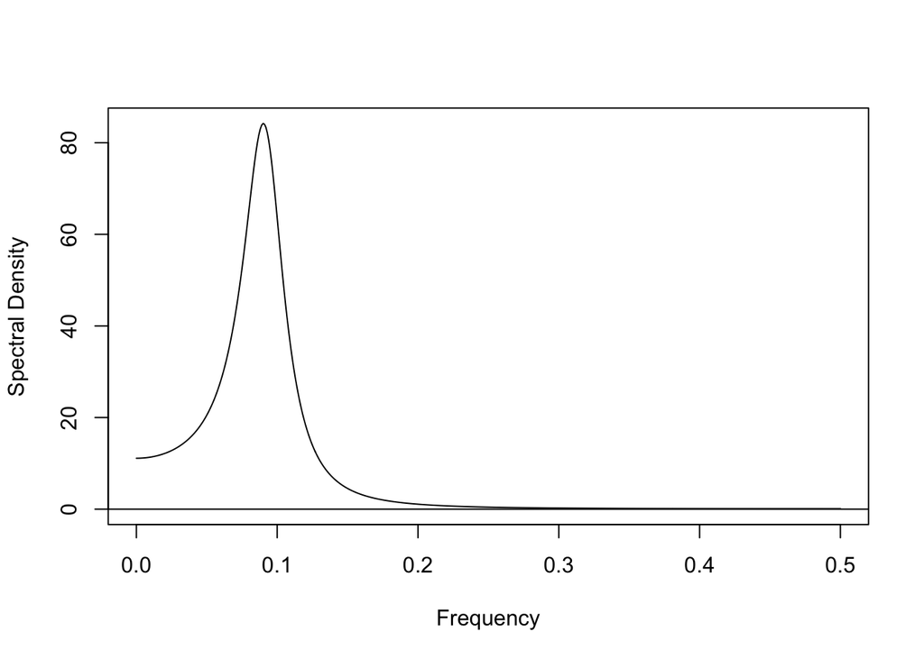

```r
library('ggplot2')

AR_model <- list(ar = c(1.5, -0.8))
ARMAspec(model = AR_model)
```

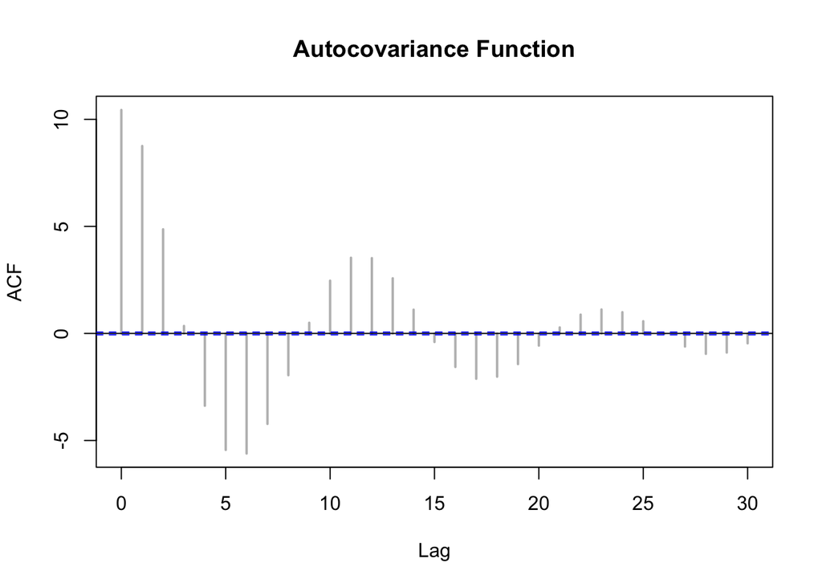

```r
model_AR <- arima.sim(model = list(ar = c(1.5, -0.8)), n=1000)
acf(model_AR, type = "covariance", main = "Autocovariance Function", col = "grey", lwd = 2)
```

### Part B

The MA(2) model is defined as:

$$X_n = \epsilon_{n-2} + \epsilon_{n-1} + \epsilon_n$$

where $\epsilon_n$ is a white noise process with variance $\sigma^2$.

The autocovariance function $\gamma(h)$ is defined as:

$$\gamma(h) = \text{Cov}(X_n, X_{n+h})$$

At lag 0, the autocovariance is simply the variance of $X_n$:

$$\gamma(0) = \text{Cov}(X_n, X_n) = \text{Var}(X_n) =
\text{Var}(\epsilon_{n-2} + \epsilon_{n-1} + \epsilon_n)$$

Since $\{\epsilon_n\}$ are independent:

$$\text{Var}(X_n) = \text{Var}(\epsilon_{n-2}) +
\text{Var}(\epsilon_{n-1}) + \text{Var}(\epsilon_n)$$

Each $\epsilon_n$ has variance $\sigma^2$, so:

$$\gamma(0) = 3\sigma^2$$

Next, for lag 1:

$$\gamma(1) = \text{Cov}(X_n, X_{n+1}) = \text{Cov}(\epsilon_{n-2} +
\epsilon_{n-1} + \epsilon_n, \epsilon_{n-1} + \epsilon_n +
\epsilon_{n+1})$$

Since $\{\epsilon_n\}$ are independent, the covariances between non-equal terms vanish. The only non-zero covariances are:

$$\text{Cov}(\epsilon_{n-1}, \epsilon_{n-1}) = \sigma^2$$

$$\text{Cov}(\epsilon_n, \epsilon_n) = \sigma^2$$

Thus, we have:

$$\gamma(1) = 2\sigma^2$$

Since $\gamma(1) = \gamma(-1)$, we conclude:

$$\gamma(-1) = 2\sigma^2$$

At lag 2 and lag -2:

$$\gamma(2) = \text{Cov}(X_n, X_{n+2}) = \text{Cov}(\epsilon_{n-2} +
\epsilon_{n-1} + \epsilon_n, \epsilon_n + \epsilon_{n+1} +
\epsilon_{n+2})$$

Again, only the terms where the indices match have non-zero covariance:

$$\text{Cov}(\epsilon_n, \epsilon_n) = \sigma^2$$

Thus:

$$\gamma(2) = \sigma^2$$

Similarly:

$$\gamma(-2) = \sigma^2$$

For any lag $h$ greater than or equal to 3, the autocovariance is zero because the white noise terms are independent. Hence, for all $|h| \geq 3$:

$$\gamma(h) = 0$$

Based on the calculations above, the autocovariance function $\gamma(h)$ for the MA(2) process is:

$$\gamma(0) = 3\sigma^2$$

$$\gamma(1) = \gamma(-1) = 2\sigma^2$$

$$\gamma(2) = \gamma(-2) = \sigma^2$$

$$\gamma(h) = 0 \quad \text{for} \quad |h| \geq 3.$$

Now, we can derive the spectral density $\lambda(\omega)$ from the autocovariance function by taking the Fourier transform:

$$\lambda(\omega) = \sum_{h=-\infty}^{\infty} \gamma(h) e^{-i\omega h}$$

Since $\gamma(h) = 0$ for $|h| \geq 3$, the sum only includes $h = 0, \pm 1, \pm 2$:

$$\lambda(\omega) = \gamma(0) + 2\gamma(1) \cos(\omega) + 2\gamma(2)
\cos(2\omega) = 3\sigma^2 + 4\sigma^2 \cos(\omega) + 2\sigma^2
\cos(2\omega) = \sigma^2 [3 + 4 \cos(\omega) + 2 \cos(2\omega)]$$

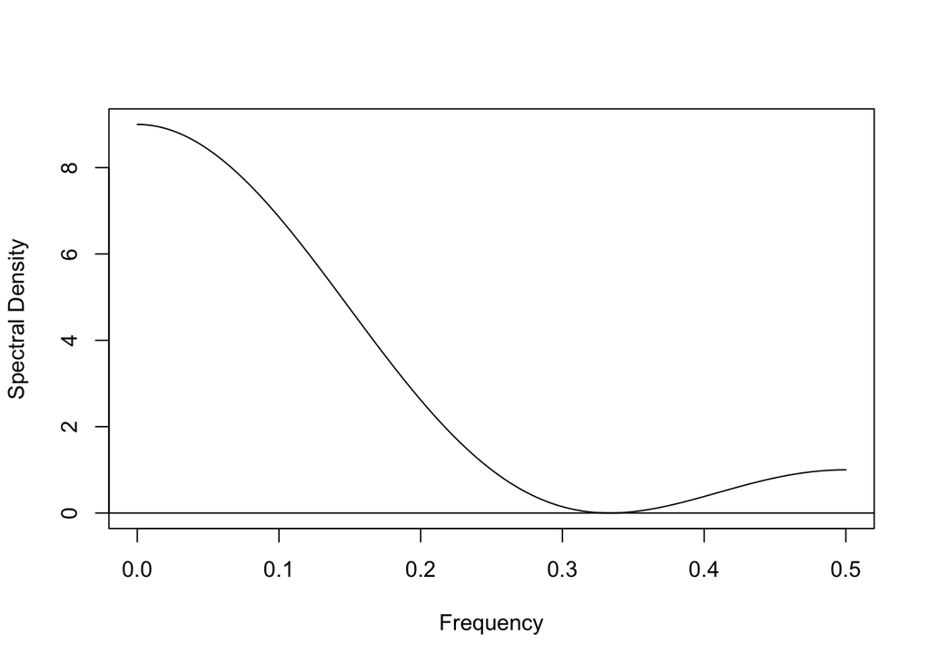

```r
ma_model <- list(ma = c(1, 1))
spec_plot <- ARMAspec(model = ma_model)
```

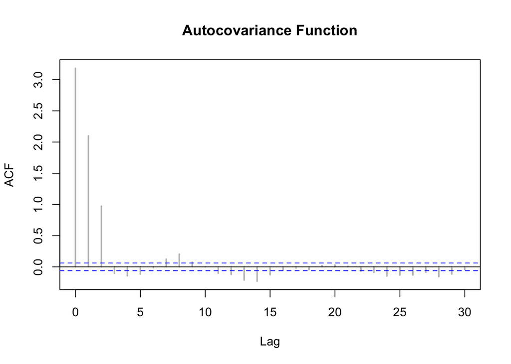

```r
model_MA <- arima.sim(model = ma_model, n = 1000)
acf_plot <- acf(model_MA, type = "covariance", main = "Autocovariance Function", col = "grey", lwd = 2)
```

### Part C

In Part A, the spectral density plot shows a distinct peak at a frequency just under 0.1, pointing to a dominant frequency that corresponds to a period slightly longer than 10. This is in line with the ACF, which demonstrates oscillations suggesting a period around 11. The close correspondence between these two plots reinforces the periodic nature of the AR(2) model.

For Part B, the spectral density does not display any sharp peaks, and the ACF lacks the oscillatory behavior typically associated with periodic processes. This lack of periodicity in both the spectrum and the ACF is indicative of the MA(2) process, which does not exhibit long-term dependencies or periodic structure, emphasizing the model’s short-memory characteristic.

*Sources*

1.”Time Series Analysis and Its Applications” by Shumway & Stoffer – Reference for time series analysis, including AR/MA models and spectral analysis.

2.”Applied Time Series Analysis” by Woodward et al. – Provides methods for analyzing time series data and autocovariance.

3.”The Elements of Statistical Learning” by Hastie et al. – Covers statistical learning techniques applicable to time series models.

4.Wikipedia: Time Series Analysis – Overview of time series concepts and models.

5.Wikipedia: Autocovariance Function – Explanation of autocovariance and its role in time series.

6.ChatAI - Debugging

## Question 4.2

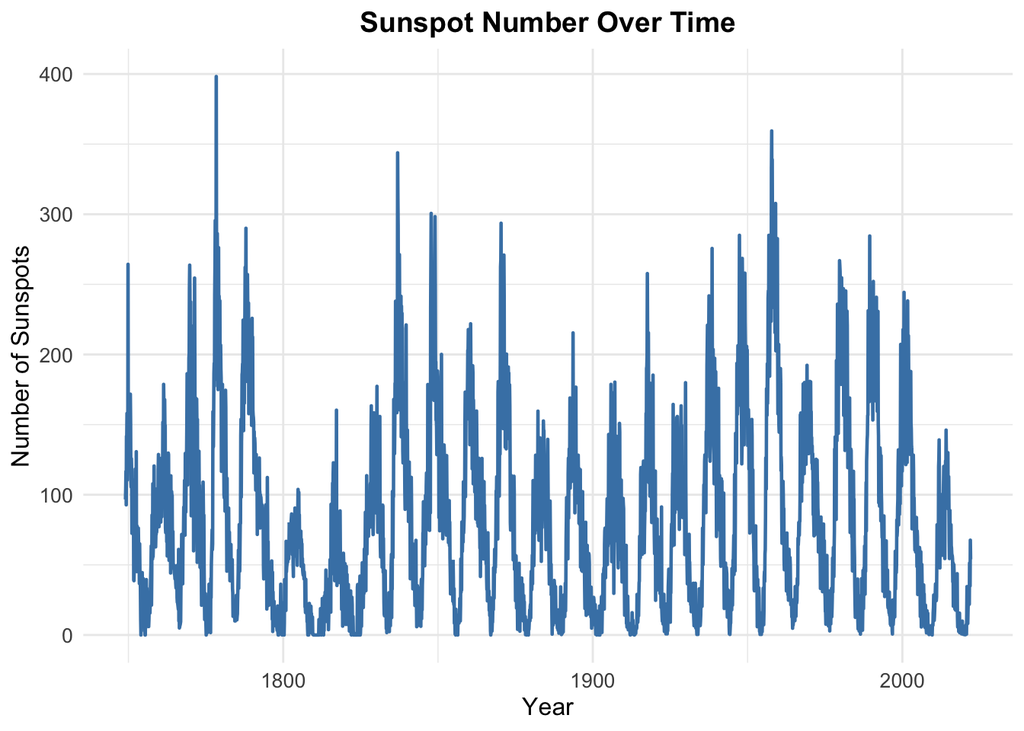

```r
data <- read.table(file="https://ionides.github.io/531w22/hw04/sunspots.txt", header = TRUE)
year <- data$Time
number <- data$Number
ggplot(data, aes(x = Time, y = Number)) +
  geom_line(color = "steelblue", size = 0.8) +
  labs(title = "Sunspot Number Over Time", x = "Year", y = "Number of Sunspots") +
  theme_minimal() +
  theme(
    plot.title = element_text(size = 14, face = "bold", hjust = 0.5),
    axis.title = element_text(size = 12),
    axis.text = element_text(size = 10)
  )
```

The time interval between the peaks in the plot is about 11 years, which aligns with the well-known 11-year solar cycle observed in sunspot activity.

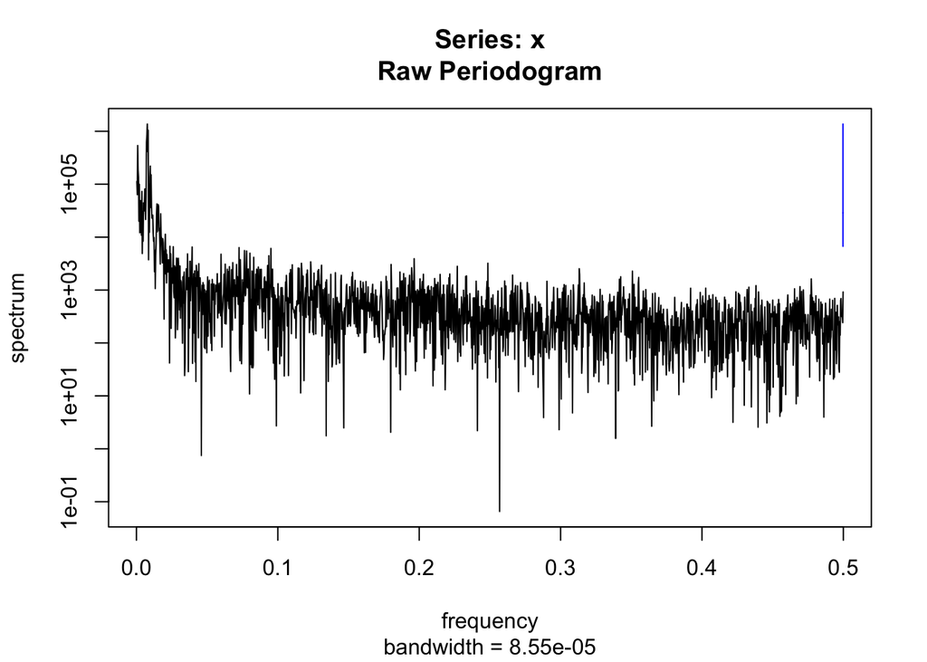

```r
sunspot_spec <- spectrum(number, plot = TRUE)
```

```r
sunspot_spec$freq[which.max(sunspot_spec$spec)]
```

```
## [1] 0.007703704
```

In the plot, we observe the raw periodogram of the time series, which displays the spectral density as a function of frequency. The x-axis represents the frequency (ranging from 0 to 0.5, which is the Nyquist frequency), and the y-axis represents the spectral density (or power at each frequency).

From the plot, we can see a dominant peak at a relatively low frequency, suggesting a prominent periodic component in the time series. This peak indicates that the time series exhibits a cyclical pattern, with the time interval between these peaks corresponding to a specific period. By estimating the frequency at the peak, we can calculate the associated period using the relationship between frequency and period:

$$\text{Period} = \frac{1}{\text{Frequency}}.$$

Based on the observed frequency in the plot (the dominant peak appears around 0.0077 month⁻¹), the estimated period corresponds to approximately 10-11 years. This aligns with the 11-year solar cycle, a well-known periodic behavior in sunspot activity.

The raw periodogram provides an initial estimate of the spectral density, showing the periodicity in the data. However, this method can be noisy, especially at high frequencies. Smoothing techniques, such as moving averages, may help to reduce this noise and provide a clearer, more reliable estimate of the dominant cycle in the data.

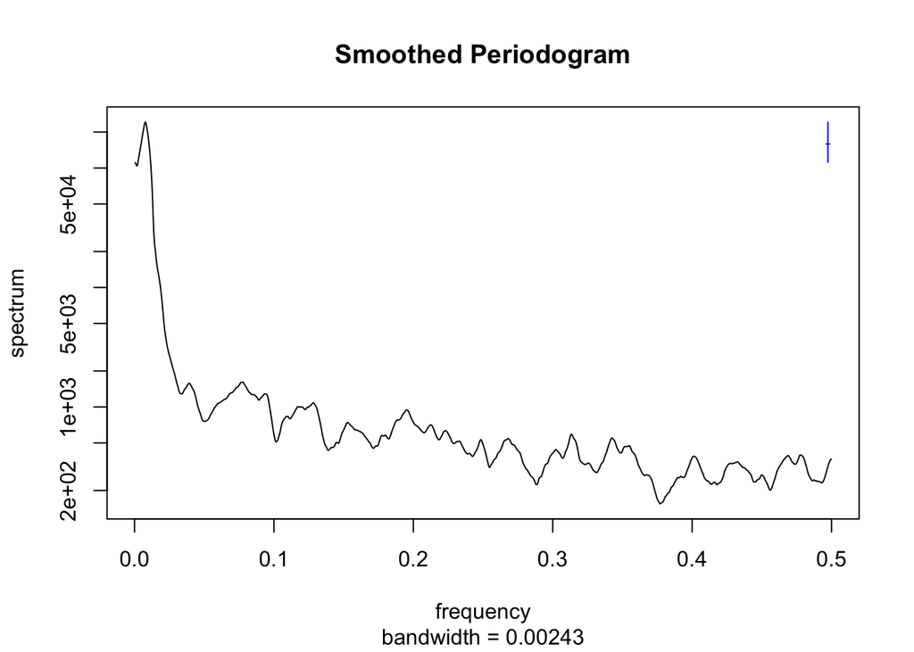

```r
sunspot_spec_smooth <- spectrum(number, spans = c(20, 20), plot = TRUE, main = "Smoothed Periodogram")
```

```r
sunspot_spec_smooth$freq[which.max(sunspot_spec_smooth$spec)]
```

```
## [1] 0.007703704
```

We applied a smoothed periodogram to the sunspot data using a moving average smoothing technique. This method reduces the noise present in the raw periodogram and provides a clearer estimate of the dominant frequency in the time series.

From the smoothed periodogram, we identified the dominant frequency by locating the maximum spectral density. The frequency corresponding to this peak is 0.00770 month⁻¹, which corresponds to a period of approximately 10.8 years. This result aligns with the known 11-year solar cycle, indicating that sunspot activity exhibits a periodic behavior consistent with solar cycles.

The smoothing process allowed us to obtain a more stable and reliable estimate of the periodicity, reducing the noise that was present in the raw periodogram.

*Sources*

1.https://www.sidc.be/SILSO/home

2.Shumway, R.H., & Stoffer, D.S. (2017). Time Series Analysis and Its Applications: With R Examples (4th ed.). Springer. - Referenced for spectral analysis and smoothing techniques in time series data.

3.Percival, D.B., & Walden, A.T. (2000). Wavelet Methods for Time Series Analysis. Wiley-Interscience. - Provides insights into wavelet methods and spectral analysis applied to time series.

4.NASA’s Sunspot Data. (n.d.). Solar and Heliospheric Observatory (SOHO). Retrieved from https://www.sidc.be/SILSO/DATA/SN_m_tot_V2.0.csv